# A Practical Guide to BERTopic for Transformer-Based Topic Modeling | Towards Data Science

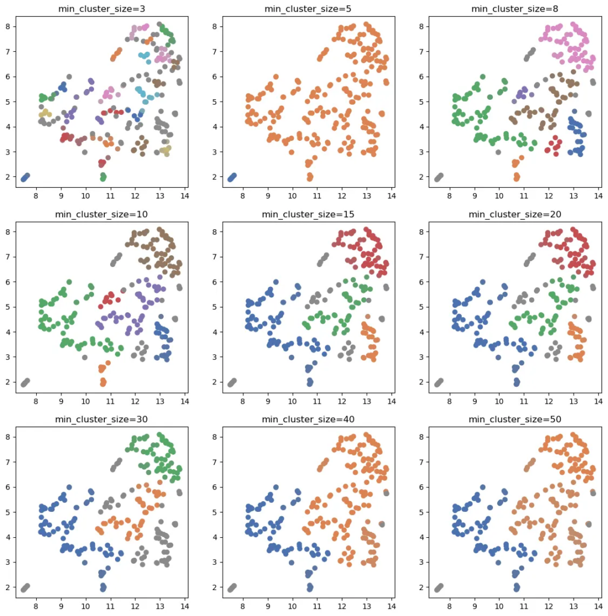

We then carry out a similar exercise to compare `min_samples` from 1 to 80 and selected `min_samples=5`. As you can observe from the visuals, the parameters `min_samples` and `min_cluster_size` exert distinct impacts on the clustering process.

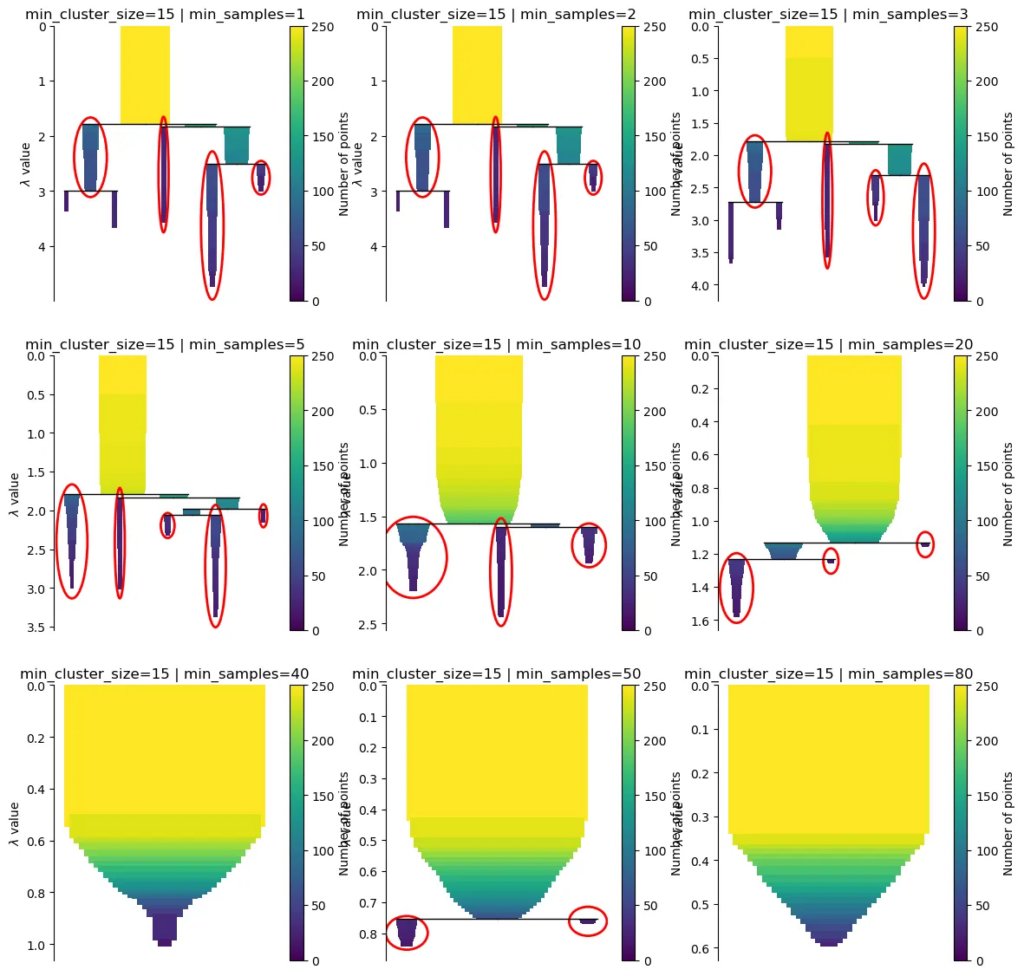

Condensed Trees for HDBSCAN `min_samples` Experimentation

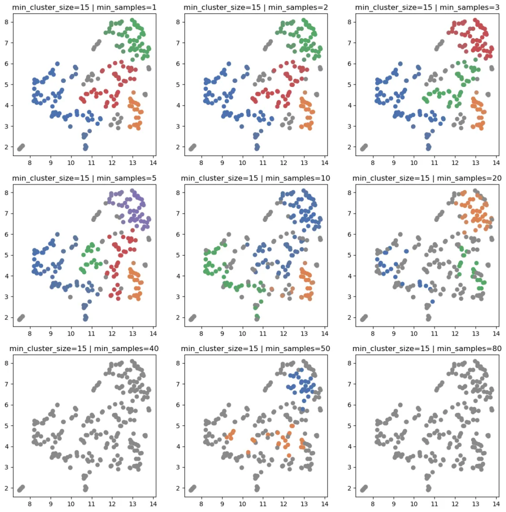

Scatterplots for HDBSCAN `min_samples` Experimentation

```python
import hdbscan

MIN_CLUSTER _SIZE= 15
MIN_SAMPLES = 5
clustering_model = hdbscan.HDBSCAN(
    min_cluster_size=MIN_CLUSTER_SIZE,
    metric='euclidean',
    cluster_selection_method='eom',
    min_samples=MIN_SAMPLES,
    random_state=0
)

topic_model = BERTopic(
    embedding_model=emb_bge,
    umap_model=umap_model,
    hdbscan_model=clustering_model,
)

topic_model.fit_transform(docs)
topic_model.get_topic_info()
```

**K-Means Experimentation**

Compared to HDBSCAN, using K-Means clustering allows us to generate more granular topics by specifying the `n_cluster` parameter, consequently, controlling the number of topics generated from the text documents.

This image shows a series of scatter plots demonstrating different clustering results when varying the number of clusters (`n_cluster`) from 3 to 50 using K-Means. With `n_cluster=3`, the data is divided into just three large groups. As `n_cluster` increases (5, 8, 10, etc.), the data points are split into more granular groupings. Overall, it forms rounded-shape clusters compared to HDBSCAN. We selected `n_cluster=8` where the clusters are neither too broad (losing important distinctions) nor too granular (creating artificial divisions). Additionally, it is a right amount of topics for categorizing 250 days of financial news. However, feel free to adjust the code snippet to your requirements if need to identify more granular or broader topics.

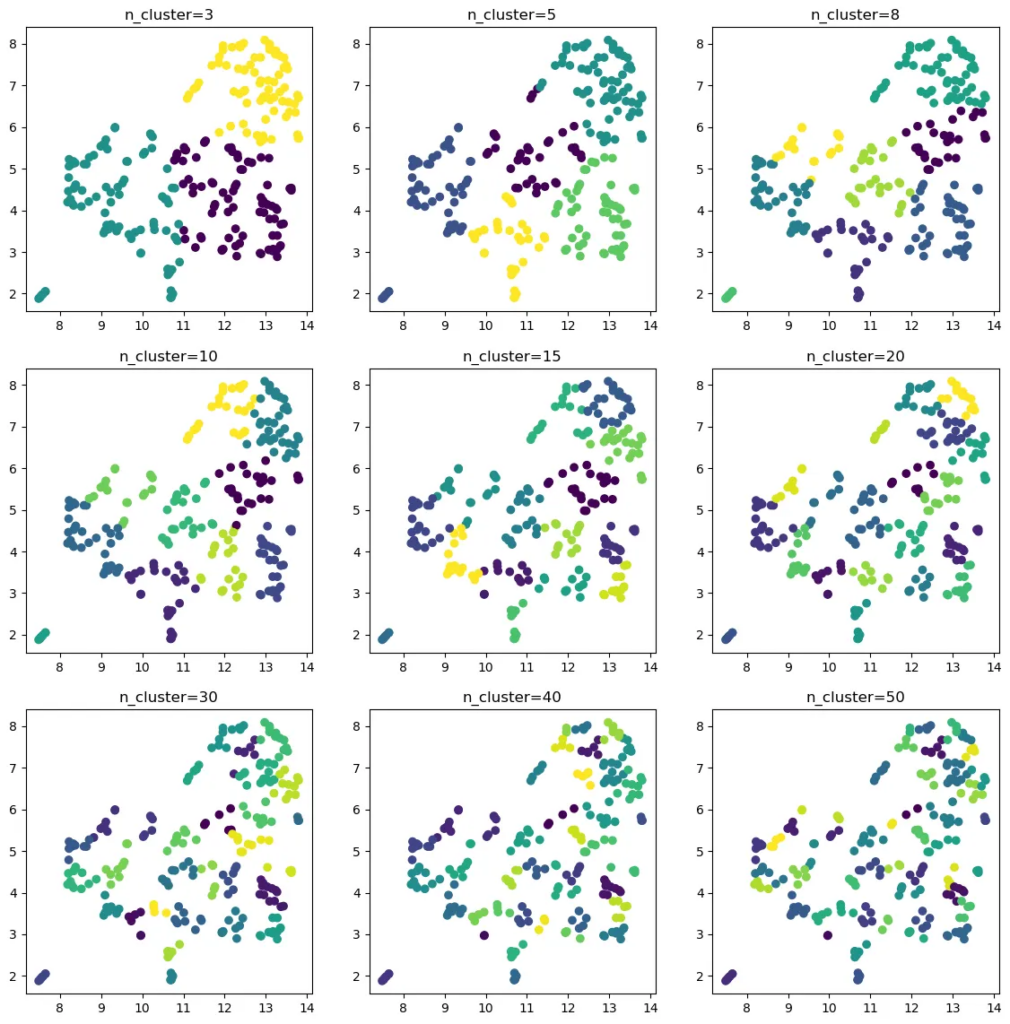

Scatterplots for K-Means `n_cluster` Experimentation

```python
from sklearn.cluster import KMeans

N_CLUSTER = 8
clustering_model = KMeans(
    n_clusters=N_CLUSTER,
    random_state=0
)

topic_model = BERTopic(
    embedding_model=emb_bge,
    umap_model=umap_model,
    hdbscan_model=clustering_model,
)

topic_model.fit_transform(docs)
topic_model.get_topic_info()
```

Comparing the topic cluster results of K-Means and HDBSCAN reveals that K-Means produces more distinct and meaningful topic representations. However, both methods still generate many stop words, indicating that subsequent modules are critical to refine the topic representations.

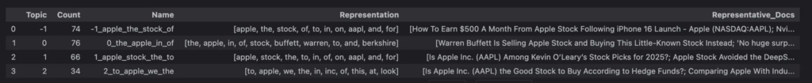

HDBSCAN Output

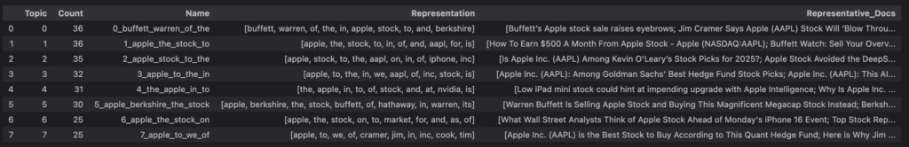

K-Means Output

### 4. Vectorizer

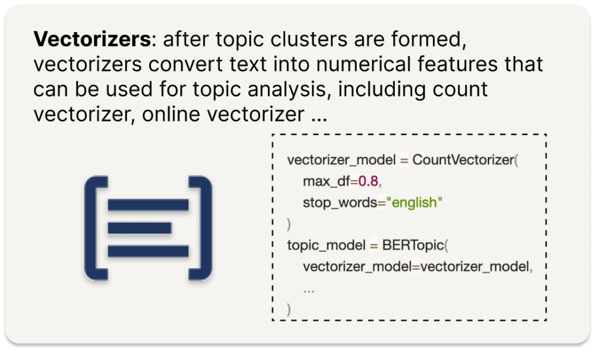

Previous modules serve the role of grouping documents into semantically similar clusters, and starting from this module the main focus is to fine-tune the topics by choosing more representative and meaningful keywords. BERTopic offers various Vectorizer options from the basic `CountVectorizer` to more advanced `OnlineCountVectorizer` which incrementally update topic representations. For this exercise, we will experiment on `CountVectorizer`, a text processing tool that creates a matrix of token counts out of a collection of documents. Each row in the matrix represents a document and each column represents a term from the vocabulary, with the values showing how many times each term appears in each document. This matrix representation enables machine learning algorithms to process the text data mathematically.

**Vectorizer Experimentation**

We will go through a few important parameters of the `CountVectorizer` and see how they might affect the topic representations.

- `ngram_range` specifies how many words to combine together into topic phrases. It is particularly useful for documents consists of short phrases, which is not needed in this situation.  
  example output if we set `ngram_range=(1, 3)`

```
0                -1_apple nasdaq aapl_apple stock_apple nasdaq_nasdaq aapl
1  0_apple warren buffett_apple stock_berkshire hathaway_apple nasdaq aapl
2           1_apple nasdaq aapl_nasdaq aapl apple_apple stock_apple nasdaq
3              2_apple aapl stock_apple nasdaq aapl_apple stock_aapl stock
4           3_apple nasdaq aapl_cramer apple aapl_apple nasdaq_apple stock
```

- `stop_words` determines whether stop words are removed from the topics, which significantly improves topic representations.
- `min_df` and `max_df` determines the frequency thresholds for terms to be included in the vocabulary. `min_df` sets the minimum number of documents a term must appear while `max_df` sets the maximum document frequency above which terms are considered too common and discarded.

We explore the effect of adding `CountVectorizer` with `max_df=0.8` (i.e. ignore words appearing in more than 80% of the documents) to both HDBSCAN and K-Means models from the previous step.

```python
from sklearn.feature_extraction.text import CountVectorizer
vectorizer_model = CountVectorizer(
		max_df=0.8,
		stop_words="english"
)

topic_model = BERTopic(
    embedding_model=emb_bge,
    umap_model=umap_model,
    hdbscan_model=clustering_model,
    vectorizer_model=vectorizer_model
)
```

Both shows improvements after introducing the `CountVectorizer`, significantly reducing keywords frequently appeared in all documents and not bringing extra values, such as “appl”, “stock”, and “apple”.

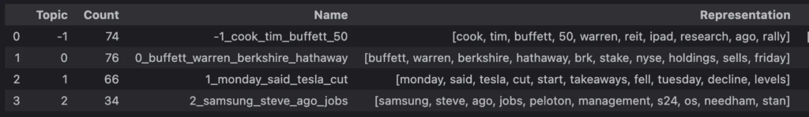

HDBSCAN Output with Vectorizer

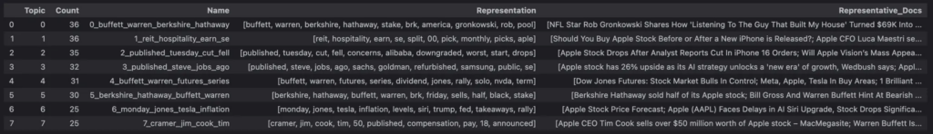

K-Means Output with Vectorizer

### 5. c-TF-IDF

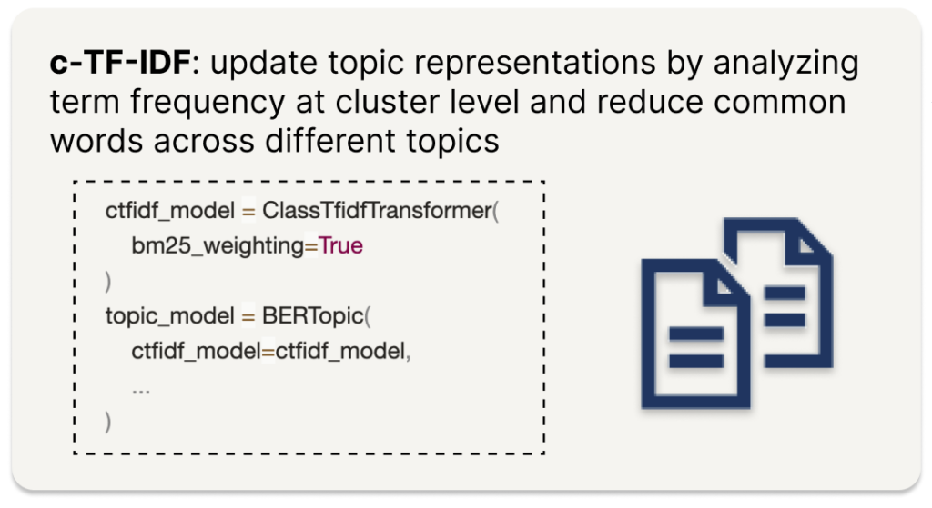

While the Vectorizer module focuses on adjusting the topic representation at the document level, c-TF-IDF mainly look at the cluster level to reduce frequently encountered topics across clusters. This is achieved by converting all documents belonging to one cluster as a single document and calculated the keyword importance based on the traditional TF-IDF approach.

**c-TF-IDF Experimentation**

- `reduce_frequent_words`: determines whether to down-weight frequently occurring words across topics
- `bm25_weighting`: when set to True, uses BM25 weighting instead of standard TF-IDF, which can help better handle document length variations. In smaller datasets, this variant can be more robust to stop words.

We use the following code snippet to add c-TF-IDF (with `bm25_weighting=True`) into our BERTopic pipeline.

```python
from bertopic.vectorizers import ClassTfidfTransformer

ctfidf_model = ClassTfidfTransformer(bm25_weighting=True)
topic_model = BERTopic(
    embedding_model=emb_bge,
    umap_model=umap_model,
    hdbscan_model=clustering_model,
    vectorizer_model=vectorizer_model,
    ctfidf_model=ctfidf_model
)
```

The topic cluster outputs below show that adding c-TF-IDF has no major impact to the end results when `CountVectorizer` has already been added. This is potentially because our `CountVectorizer` has already set a high bar of eliminating words appearing in more than 80% at the document level. Subsequently, this already reduces overlapping vocabularies at the topic cluster level, which is what c-TF-IDF is intended to achieve.

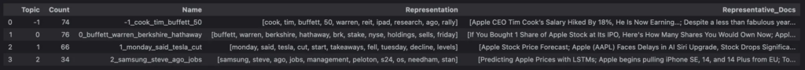

HDBSCAN Output with Vectorizer and c-TF-IDF

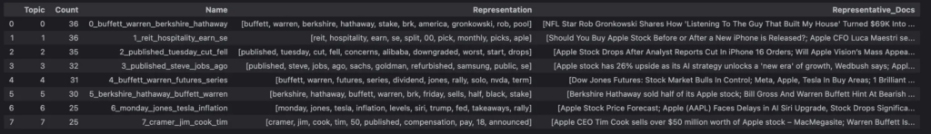

K-Means Output with Vectorizer and c-TF-IDF

However, If we replace `CountVectorizer` with c-TF-IDF, although the result below shows slight improvements compared to when both are not added, there are too many stop words present, making the topic representations less valuable. Therefore, it appears that for the documents we are dealing with in this scenario, c-TF-IDF module does not bring extra value.

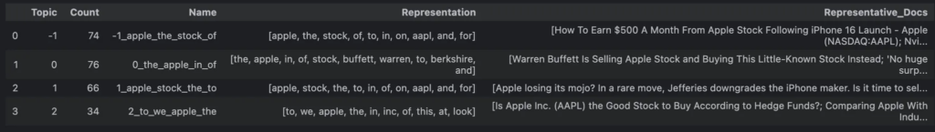

HDBSCAN Output with c-TF-IDF only

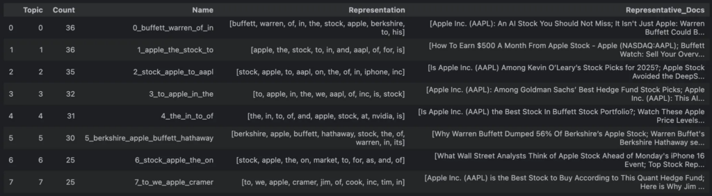

K-Means Output with c-TF-IDF only